# Fonction native *sorted*

## 1. Problématique

Comparons les performances du tri par insertion à celles de la fonction native *sorted*.

```python
from time import time

def duree_tri(fonction, t: tuple)->tuple:
    deb = time()
    fonction(list(t))
    fin = time()
    return (fonction.__name__, fin-deb)

def tri_insertion(tab):
    taille = len(tab)
    for i in range(1,taille):
        en_cours = tab[i]
        j = i-1
        while j >= 0 and tab[j] > en_cours:
            tab[j+1] = tab[j]
            j -= 1
        tab[j+1] = en_cours
    return tab
```

```python
from random import randint

l = tuple(randint(0,100) for _ in range(10000))
print(duree_tri(tri_insertion, l))
```

```
('tri_insertion', 5.1087799072265625)
```

```python
print(duree_tri(sorted, l))
```

```
('sorted', 0.0018515586853027344)
```

### Quel algorithme de tri est implémenté dans la fonction *sorted*?

## 2. Nouvelle approche

### 2.1 Résoudre de petits problèmes...

Une liste de un élément est triée.

| 8 |  | 5 |  | 4 |  | 7 |  | 9 |  | 6 |  | 3 |
| --- | --- | --- | --- | --- | --- | --- | --- | --- | --- | --- | --- | --- |

fusionner(liste gauche, liste droite)

| 5 | 8 |  | 4 | 7 |  | 6 | 9 |  | 3 |
| --- | --- | --- | --- | --- | --- | --- | --- | --- | --- |

fusionner(liste gauche, liste droite)

| 4 | 5 | 7 | 8 |  | 3 | 6 | 9 |
| --- | --- | --- | --- | --- | --- | --- | --- |

fusionner(liste gauche, liste droite)

| 3 | 4 | 5 | 6 | 7 | 8 | 9 |
| --- | --- | --- | --- | --- | --- | --- |

### 2.2 ... Pour solutionner de gros problèmes

Décomposons un gros problèmes en petits.

| 8 | 5 | 4 | 7 | 9 | 6 | 3 |
| --- | --- | --- | --- | --- | --- | --- |

décomposer en deux listes et recommencer sur ces deux listes

| 8 | 5 | 4 | 7 |  | 9 | 6 | 3 |
| --- | --- | --- | --- | --- | --- | --- | --- |

décomposer en deux listes et recommencer sur ces deux listes

| 8 | 5 |  | 4 | 7 |  | 9 | 6 |  | 3 |
| --- | --- | --- | --- | --- | --- | --- | --- | --- | --- |

décomposer en deux listes et recommencer sur ces deux listes

| 8 |  | 5 |  | 4 |  | 7 |  | 9 |  | 6 |  | 3 |
| --- | --- | --- | --- | --- | --- | --- | --- | --- | --- | --- | --- | --- |

### 2.3 Diviser pour régner: un algorithme récursif

- On appelle récursivement la fonction de tri pour décomposer en sous-listes.
- On fusionne les sous-listes en remontant la pile d'appel.

$$ tri(liste) = \left\{ \begin{array}{ll} liste & \mbox{si la taille de liste} \leq 1 \\ fusionner(\mbox{tri(liste gauche), tri(liste droite))} & \mbox{sinon } \end{array} \right. $$

### 2.4 L'étape de fusion

**Activité 1:** Écrire une fonction $fusionner(gauche: list, droite: list)\;\rightarrow\;list$ qui renvoie une liste triée composée des éléments de *gauche* et *droite* déjà triées.

Correction

```python
def fusionner(gauche: list, droite: list)-> list:
    res = []
    i,j = 0,0
    while i < len(gauche) and j < len(droite):
        if droite[j] <= gauche[i]:
            res.append(droite[j])
            j += 1
        else:
            res.append(gauche[i])
            i += 1

    #ajout de la fin de liste restante
    if i == len(gauche):
        res.extend(droite[j:])
    if j == len(droite):
        res.extend(gauche[i:])
    return res
```

```python
gauche = [3,4,8,15]
droite = [1,2,6,9]
fusionner(gauche,droite)
```

```
[1, 2, 3, 4, 6, 8, 9, 15]
```

```python
def fusionner2(gauche: list,droite: list)->list:
    res = []
    while gauche and droite:
        if gauche[0] <= droite[0]:
            res.append(gauche.pop(0))
        else:
            res.append(droite.pop(0))

    #ajout de la fin de liste restante
    if gauche:
        res.extend(gauche)
    if droite:
        res.extend(droite)
    return res
```

```python
gauche = [3,4,8,15]
droite = [1,2,6,9]
fusionner2(gauche,droite)
```

```
[1, 2, 3, 4, 6, 8, 9, 15]
```

### 2.5 Le code complet du tri fusion

#### Activité 2

$$ tri(liste) = \left\{ \begin{array}{ll} liste & \mbox{si la taille de liste} \leq 1 \\ fusionner(\mbox{tri(liste gauche), tri(liste droite))} & \mbox{sinon } \end{array} \right. $$

Correction

```python
def tri_fusion(tab):
    taille = len(tab)
    if taille <= 1:
        return tab
    else:
        milieu = taille//2
        return fusionner(tri_fusion(tab[:milieu]), tri_fusion(tab[milieu:]))
```

## 3. Performances du tri fusion

```python
l = tuple(randint(0,100) for _ in range(10000))
print(duree_tri(tri_fusion, l))
print(duree_tri(sorted, l))
```

```
('tri_fusion', 0.12418222427368164)
('sorted', 0.001750946044921875)
```

## 3.2 Complexité

### 3.2.1 Découper en sous-listes

$$\dfrac{n}{2^a}=1$$

Le logarithme base 2 noté $log_2$ se définit: $log_2(2^x)=x$.

### 3.2.2 Fusionner deux listes

```python
def fusionner(gauche: list, droite: list)-> list:
    res = []
    i,j = 0,0

    # Chaque liste n'est parcourue qu'une seule fois
    # Le parcours est en O(n)

    while i < len(gauche) and j < len(droite):
        if droite[j] <= gauche[i]:
            res.append(droite[j])
            j += 1
        else:
            res.append(gauche[i])
            i += 1

    #ajout de la fin de liste restante
    if i == len(gauche):
        res.extend(droite[j:])
    if j == len(droite):
        res.extend(gauche[i:])
    return res
```

[figure not shown]

### 3.2.3 Complexité du tri fusion

La complexité du tri fusion est en $O(n×log_2(n))$.

```python
import matplotlib.pyplot as plt

def evolution_duree(fonction,cadre):
    nb_elements=[10,100,250,500,750,1000,1500,2000,3000,3500,5000,7500,10000,13000,16000,24000]
    temps = []
    #calculs des durées
    for nb in nb_elements:
        tab = [randint(0,100) for _ in range(nb)]
        temps.append(duree_tri(fonction,tab)[1])

    #création du graphe
    p = plt.subplot(1,2,cadre)
    plt.plot(nb_elements,temps)

    #habillage
    plt.title(fonction.__name__)
    p.xaxis.set_tick_params(labelsize=16)
    p.yaxis.set_tick_params(labelsize=16)
    plt.grid()

def affichage():
    plt.figure(figsize=(20,10))
    evolution_duree(tri_insertion,1)
    evolution_duree(tri_fusion,2)
    plt.show()
```

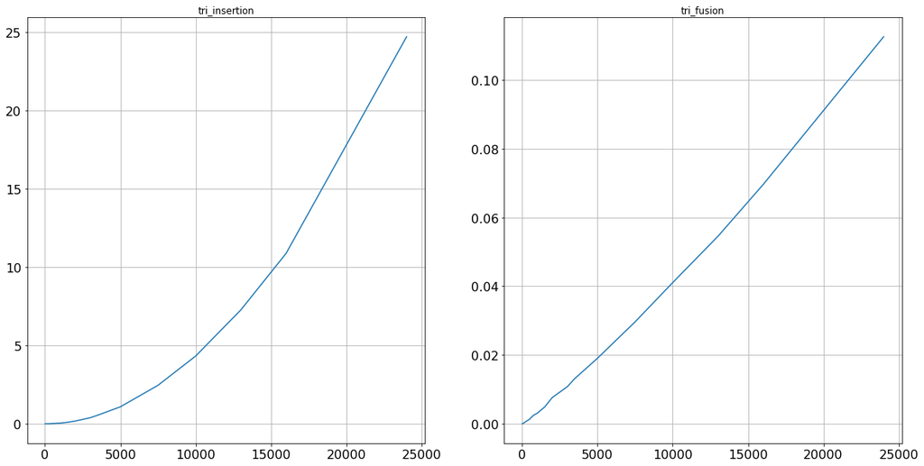

```python
affichage()
```

### 3.3 Stabilité

Un algorithme de tri **stable** maintient l'ordre relatif des clés égales de l'entrée.

**Entrée:** (1, 2) (9, 7) (3, 4) (8, 6) (9, 3)

**Sortie stable:** (1, 2) (3, 4) (8, 6) (9, 7) (9, 3)

**Sortie instable:** (1, 2) (3, 4) (8, 6) (9, 3) (9, 7)

## 4. La fonction native *sorted*

Elle implémente l'algorithme **Timsort** mis au point par Tim Peters en 2002. C'est un algorithme hybride de plusieurs tris.

#### Activité 6: Réaliser une présentation de l'algorithme Timsort

Le format de retour peut-être un pdf ou un jupyter.